# Predicting Survival Rate on Titanic

## Task

**The data is obtained from https://www.kaggle.com/c/titanic. The aim of the task was to use machine learning to create a model that predicts which passengers survived the Titanic shipwreck**

*The overall goal for this kaggle dataset was to get started in how competitions work and how it is assessed to further compete in future competitions*

*I will explore the data and perform pre-processing techniques to make the data set suitable for the model fitting that follows.*

*A quick graph analysis of suitable attributes to the response target variable (Survived) is also performed to also identify key variables that impact the probability of survival rate through inspection*

*Implementation of classication models using each of the following techniques are also used to determine the feature importance within the dataset.*  
*- Decision Tree*  
*- Bagging*  
*- Boosting*  
*- Random Forest*

Full report can be found on my github: https://github.com/TingHanGan/titanic-kaggle.

### Decision Tree Produced

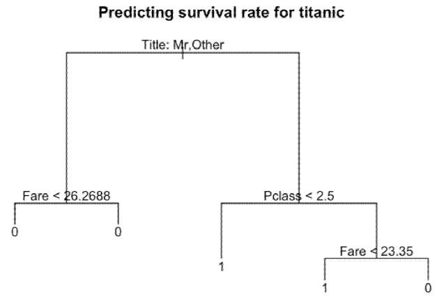